# Clase 16 - Guía Modelos Lineales Mixtos

Diplomado en Análisis de datos con R para la Acuicultura

Dr. José A. Gallardo y Dra. María Angélica Rueda.

Pontificia Universidad Católica de Valparaíso  
jose.gallardo@pucv.cl

31 May 2022

### MODELOS LINEALES MIXTOS

Los modelos lineales mixtos (MLM) son una generalización del modelo lineal de regresión clásico, contemplando la posible existencia de observaciones correlacionadas (ej. Medidas repetidas en el mismo individuo) o con variabilidad heterogénea, vinculadas a la presencia de factores aleatorios.

**Efecto fijo**: Los efectos fijos solo estiman medias de las variables predictoras.

**Efecto aleatorio**: Los efectos aleatorios estiman varianzas.

Caracteristicas de un modelo lineal mixto (MLM)

1). El MLM está conformado por efectos fijos y efectos aleatorios.

2). La variable respuesta debe tener ditribución normal.

3). Existencia de observaciones correlacionadas.

4). Puede existir heterogeneidad de varianzas.

Incumplimiento de supuestos (1 y 3):

1. Hay observaciones correlacionadas.
2. Los residuos se distribuyen **normalmente**.
3. No hay homogeneidad de varianzas.

#### **Objetivos de aprendizaje**

Los objetivos de aprendizaje de esta guía son:

**1**. - Identificar efectos fijos y efectos aleatorios.

**3**. - Ajustar modelos lineales mixtos.

**3**. - Realizar gráficas avanzadas con ggplot2.

**4**. - Elaborar un reporte dinámico en formato pdf con **[Rmarkdown](https://rmarkdown.rstudio.com/)**.

## ESTUDIO DE CASO: PIOJO EN SALMÓN

En este estudio de caso trabajaremos con un set de datos de salmón (n=354) publicado en la revista [JOURNAL OF EVOLUTIONARY BIOLOGY](https://onlinelibrary.wiley.com/doi/epdf/10.1111/jeb.13082)

La variable respuesta se denomina **Totalareadamage** y las variables predictoras **Status**, **Nbfemales**, **DaysPI** como efectos fijos y **Tank** como efecto aleatorio. La variable Status es cualitativa y Nbfemales, DaysPI son variables cuantiativas discretas.

### **Ejercicio 1.** Elaborar y configurar Reporte en formato .Rmd

Elabore un documento .Rmd y configure su reporte para exportar en .htlm. Instale solo las librerías que utilice para el análisis de los datos.

```r
knitr::opts_chunk$set(echo = TRUE)
library(readxl)
library(ggplot2)
library(dplyr)
library(multcomp)
library(psych)
library(car)
library(nlme)
library(lme4)
library(readr)
library(lmtest)
library(sjPlot)
```

Ejecute cada uno de los siguientes ejercicios en uno o más bloques de códigos diferentes. Sea ordenado y documente su reporte adecuadamente.

### **Ejercicio 2.** Exploratorio set de datos UGELVIK_et_al_2017.xlsx

Importe el set de datos **UGELVIK_et_al_2017.xlsx** y llame al objeto **datos_salmones**. Primero, omita los valores faltantes de la base de datos con la función na.omit(). Segundo, seleccione las variables **Tank**, **Status**, **Nbfemales**, **DaysPI** y **Totalareadamage** de la base de datos datos_salmones. Para finalizar,realice un análisis exploratorio de datos.

**a).** Resumen estadístico de todas las variables.

```r
datos_salmones <- read_excel("UGELVIK_et_al_2017.xlsx")
datos_salmones <- na.omit(datos_salmones)
datos_salmones <- datos_salmones[,c("Tank","Status", "Nbfemales", "DaysPI", "Totalareadamage")]
summary(datos_salmones)
```

```
##       Tank          Status            Nbfemales          DaysPI
##  Min.   : 1.00   Length:354         Min.   : 0.000   Min.   :  0.00
##  1st Qu.:14.00   Class :character   1st Qu.: 1.000   1st Qu.: 67.25
##  Median :30.00   Mode  :character   Median : 3.000   Median : 87.00
##  Mean   :29.75                      Mean   : 2.992   Mean   : 82.63
##  3rd Qu.:45.00                      3rd Qu.: 4.000   3rd Qu.:105.00
##  Max.   :60.00                      Max.   :13.000   Max.   :133.00
##  Totalareadamage
##  Min.   :  0.00
##  1st Qu.: 52.31
##  Median : 96.57
##  Mean   :124.29
##  3rd Qu.:165.11
##  Max.   :670.98
```

**b).** Transforme las variables Tank y Status en factores. Luego, pida el summary() de la base de datos datos_salmones.

```r
datos_salmones$Tank <- as.factor(datos_salmones$Tank)
datos_salmones$Status <- as.factor(datos_salmones$Status)
summary(datos_salmones)
```

```
##       Tank        Status      Nbfemales          DaysPI       Totalareadamage
##  4      :  9   Farmed:175   Min.   : 0.000   Min.   :  0.00   Min.   :  0.00
##  5      :  9   Wild  :179   1st Qu.: 1.000   1st Qu.: 67.25   1st Qu.: 52.31
##  7      :  9                Median : 3.000   Median : 87.00   Median : 96.57
##  23     :  9                Mean   : 2.992   Mean   : 82.63   Mean   :124.29
##  2      :  8                3rd Qu.: 4.000   3rd Qu.:105.00   3rd Qu.:165.11
##  8      :  8                Max.   :13.000   Max.   :133.00   Max.   :670.98
##  (Other):302
```

**c).** Histograma de la variable respuesta **Totalareadamage**.

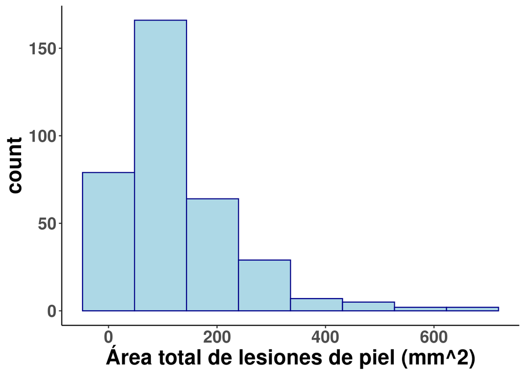

```r
ggplot(datos_salmones, aes(x=Totalareadamage))+
  geom_histogram(color="darkblue", fill="lightblue", bins = 8)+theme_classic()+theme(text = element_text(size=20,face="bold",colour="black"))+xlab("Área total de lesiones de piel (mm^2)")
```

**d).** Transforme la variable respuesta **Totalareadamage** usando la raíz cuadrada, use la función sqrt(Totalareadamage) y agregue esa variable al set de datos_salmones. Llame a esa variable rc_area_damage. Use la función mutate.

```r
datos_salmones <- datos_salmones %>%
                  mutate(rc_area_damage=sqrt(Totalareadamage))
```

**e).** Histograma de la variable respuesta transformada **rc_area_damage**.

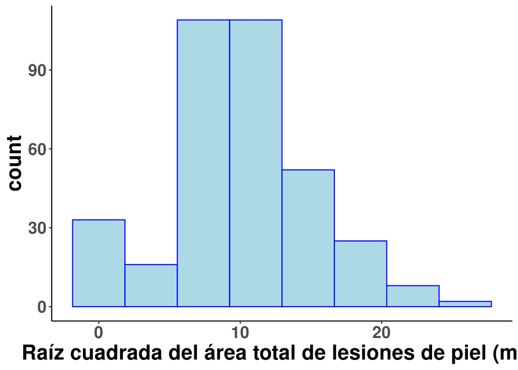

```r
ggplot(datos_salmones, aes(x=rc_area_damage))+
  geom_histogram(color="blue", fill="lightblue", bins = 8)+theme_classic()+theme(text = element_text(size=20,face="bold",colour="black"))+xlab("Raíz cuadrada del área total de lesiones de piel (mm)")
```

**f).** Realice el exploratorio de los datos

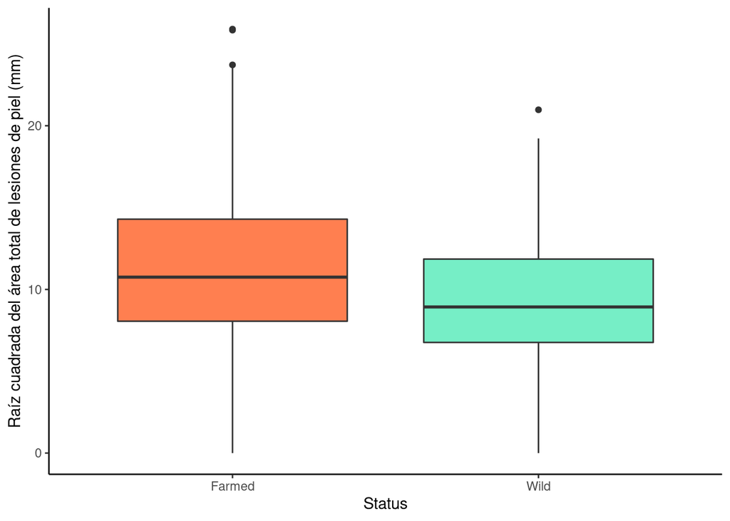

```r
ggplot(data = datos_salmones,aes(x= Status, y = rc_area_damage)) +
  geom_boxplot(fill=c("coral", "aquamarine2")) + theme(legend.position = 'right')+ theme_classic()+ylab("Raíz cuadrada del área total de lesiones de piel (mm)")
```

### **Ejercicio 3.** Modelo de efectos fijos

**a).** Ajuste un modelo donde la variable respuesta sea **rc_area_damage** y como efectos fijos del modelo las variables **Status**, **Nbfemales** y **DaysPI**. Use la función **lm()**, **summary()**.

Interprete los resultados del modelo ajustado y responda las siguientes preguntas:  
- ¿Los coeficientes estimados son estadísticamente significativos? - ¿Cuál es la bondad de ajuste del modelo $R^2$ ajustado?

```r
mod.1 <- lm(rc_area_damage ~ Status+ Nbfemales+ DaysPI, data = datos_salmones)

pander::pander(summary(mod.1), caption = "Modelo de efectos fijos")
```

|  | Estimate | Std. Error | t value | Pr(>\|t\|) |
| --- | --- | --- | --- | --- |
| **(Intercept)** | 5.334 | 0.7169 | 7.44 | 7.884e-13 |
| **StatusWild** | -1.581 | 0.4757 | -3.324 | 0.0009811 |
| **Nbfemales** | 0.6966 | 0.1048 | 6.646 | 1.155e-10 |
| **DaysPI** | 0.04025 | 0.007536 | 5.34 | 1.672e-07 |

Modelo de efectos fijos

| Observations | Residual Std. Error | $R^2$ | Adjusted $R^2$ |
| --- | --- | --- | --- |
| 354 | 4.402 | 0.2463 | 0.2399 |

**OTRA FORMA DE VER LOS RESULTADOS DEL SUMMARY CON FORMATO TABLA DE HTML**

```r
# PARA HACER TABLA CON RESULTADOS DEL OBJETO mod.1
tab_model(mod.1, show.se = TRUE, show.aic=TRUE)
```

|  | rc_area_damage |  |  |  |
| --- | --- | --- | --- | --- |
| Predictors | Estimates | std. Error | CI | p |
| (Intercept) | 5.33 | 0.72 | 3.92 – 6.74 | **<0.001** |
| Status [Wild] | -1.58 | 0.48 | -2.52 – -0.65 | **0.001** |
| Nbfemales | 0.70 | 0.10 | 0.49 – 0.90 | **<0.001** |
| DaysPI | 0.04 | 0.01 | 0.03 – 0.06 | **<0.001** |
| Observations | 354 |  |  |  |
| R<sup>2</sup> / R<sup>2</sup> adjusted | 0.246 / 0.240 |  |  |  |
| AIC | 2059.847 |  |  |  |

### **Ejercicio 4.** Modelo lineal mixto

**a).** Ajuste un modelo donde la variable respuesta sea **rc_area_damage**, como efectos fijos del modelo las variables **Status**, **Nbfemales** y **DaysPI** y como efecto aleatorio **Tank**. Use la función **lmer()**, **summary()**.

```r
mod.2 <- lmer(rc_area_damage ~ Status+ Nbfemales+ DaysPI+ (1|Tank), data = datos_salmones)
summary(mod.2)
```

```
## Linear mixed model fit by REML ['lmerMod']
## Formula: rc_area_damage ~ Status + Nbfemales + DaysPI + (1 | Tank)
##    Data: datos_salmones
##
## REML criterion at convergence: 1874.8
##
## Scaled residuals:
##     Min      1Q  Median      3Q     Max
## -2.4985 -0.5564 -0.0133  0.4603  4.1041
##
## Random effects:
##  Groups   Name        Variance Std.Dev.
##  Tank     (Intercept) 16.996   4.123
##  Residual              7.487   2.736
## Number of obs: 354, groups:  Tank, 58
##
## Fixed effects:
##              Estimate Std. Error t value
## (Intercept)  5.182130   0.886362   5.847
## StatusWild  -0.929802   1.078737  -0.862
## Nbfemales    1.550608   0.100147  15.483
## DaysPI       0.004304   0.005352   0.804
##
## Correlation of Fixed Effects:
##            (Intr) SttsWl Nbfmls
## StatusWild -0.630
## Nbfemales  -0.152  0.047
## DaysPI     -0.321 -0.008 -0.450
```

**OTRA FORMA DE VER LOS RESULTADOS DEL SUMMARY CON FORMATO TABLA DE HTML**

|  | rc_area_damage |  |  |  |
| --- | --- | --- | --- | --- |
| Predictors | Estimates | std. Error | CI | p |
| (Intercept) | 5.18 | 0.89 | 3.42 – 6.94 | **<0.001** |
| Status [Wild] | -0.93 | 1.08 | -3.09 – 1.23 | 0.394 |
| Nbfemales | 1.55 | 0.10 | 1.35 – 1.75 | **<0.001** |
| DaysPI | 0.00 | 0.01 | -0.01 – 0.01 | 0.423 |
| Random Effects |  |  |  |  |
| σ<sup>2</sup> | 7.49 |  |  |  |
| τ<sub>00</sub> <sub>Tank</sub> | 17.00 |  |  |  |
| ICC | 0.69 |  |  |  |
| N <sub>Tank</sub> | 58 |  |  |  |
| Observations | 354 |  |  |  |
| Marginal R<sup>2</sup> / Conditional R<sup>2</sup> | 0.366 / 0.806 |  |  |  |
| AIC | 1886.784 |  |  |  |

### **Ejercicio 5.** Comparación y selección de modelos

**a).** Realice la comparación de modelos con la función AIC().

- ¿Cuál es el mejor modelo?
- ¿Hubo mejoría al incorporar el efecto aleatorio de Tanque?

```r
AIC(mod.1, mod.2)
```

```
##       df      AIC
## mod.1  5 2059.847
## mod.2  6 1886.784
```